# Preliminary Data Exploration of Patients with AD

## Introduction

This R Markdown document details the steps of preliminary exploratory analysis conducted on the MAARS dataset for preparing for the analysis to determine the connections between atopic dermititis lesioned and non-lesioned skin samples.

## Preparation

Load libraries, load data, and prepare the data.

```r
# load libraries
library(ggplot2)
library(dplyr)
library(qdapTools)
library(kableExtra)

# set working directory
setwd("/Users/thewooz/Documents/Omics-Project")

# load the data
all_data<- read.csv("/Users/thewooz/Documents/Omics-Project/filter-data/all.csv")
ad_full<-  read.csv("/Users/thewooz/Documents/Omics-Project/filter-data/ad_full.csv")

# order the clinical groups
all_data$clinical_group<- factor(all_data$clinical_group, levels=c("AD","PSO","CTRL"))

# rename the factors for lesional/non-lesional
levels(all_data$lesional) <- c("Lesional","Non-Lesional")

# reduce the all_data file to include just the AD samples
ad_data<- subset(all_data, all_data$clinical_group == 'AD')

# create dataset of unique participants
reduce<- ad_data[ ,c(6,2,7:34)]
undup_AD<- reduce[!duplicated(reduce$MAARS_identifier), ]

# report data up to 4 digits
options(digits=4)
```

## Describe the AD Participants

Demographics (gender, age, race) of the participants in the AD clinical group.

```r
# gender (number, percent)
gend_tab<- as.data.frame(table(undup_AD$Gender))
gend_tab<- mutate(gend_tab, Percent=Freq/sum(Freq)*100)
colnames(gend_tab)[colnames(gend_tab)=="Var1"]<- ""
gend_tab %>% kable(caption = "Gender") %>% kable_styling(bootstrap_options = "striped", full_width = F)
```

Gender

|  | Freq | Percent |
| --- | --- | --- |
| Female | 38 | 44.19 |
| Male | 48 | 55.81 |

```r
# race (number, percent)
race_tab<- as.data.frame(table(ad_full$patient.Diagnostic...Phenotypic.Data.Ethnicity.Family.History.Ethnicity..Ethnicity.))
race_tab<- mutate(race_tab, Percent=Freq/sum(Freq)*100)
colnames(race_tab)[colnames(race_tab)=="Var1"]<- ""
race_tab %>% kable(caption = "Race") %>% kable_styling(bootstrap_options = "striped", full_width = F)
```

Race

|  | Freq | Percent |
| --- | --- | --- |
| Asian - Other | 2 | 2.326 |
| Black - African | 3 | 3.488 |
| Black - Caribbean | 3 | 3.488 |
| Black - Other | 1 | 1.163 |
| White | 77 | 89.535 |

```r
# age (min, max, mean, SD)
age<-
  undup_AD %>%
  summarize(Min=min(CUSTOM_Age, na.rm=TRUE),
            Max=max(CUSTOM_Age, na.rm=TRUE),
            Mean=mean(CUSTOM_Age, na.rm=TRUE),
            SD=sd(CUSTOM_Age, na.rm=TRUE))
age %>% kable(caption = "Age") %>% kable_styling(bootstrap_options = "striped", full_width = F)
```

Age

| Min | Max | Mean | SD |
| --- | --- | --- | --- |
| 20 | 83 | 43.86 | 14.57 |

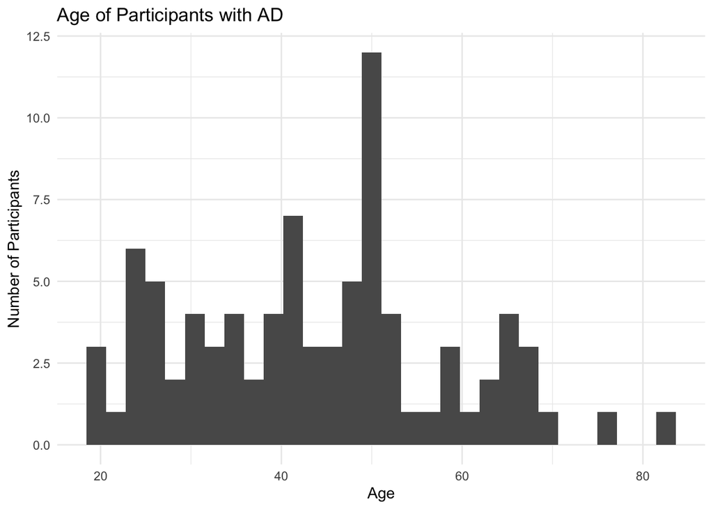

```r
# histogram: age
ggplot2::ggplot(data=undup_AD, aes(x=CUSTOM_Age))+
  geom_histogram()+
  theme_minimal()+
  xlab("Age")+
  ylab("Number of Participants")+
  ggtitle("Age of Participants with AD")
```

## Clinical Characteristics of the AD Group

Describe the clinical characteristics of the AD group.

```r
# number/percent of AD patients with each type of allergy
allergies<- (mtabulate(undup_AD[grep('Allergies',names(undup_AD), value=T)]))
allergies$Percent<- (allergies[,2]/(allergies[,1]+allergies[,2]))*100
row.names(allergies)<- c("Psuedo Drug","Dust Mite","Food","Pollen","Contact", "Drug","Animal")
p_allergies<-allergies[ ,2:3]
colnames(p_allergies)[colnames(p_allergies)=="True"]<- "Freq"
p_allergies %>% kable(caption = "Allergies") %>% kable_styling(bootstrap_options = "striped", full_width = F)
```

Allergies

|  | Freq | Percent |
| --- | --- | --- |
| Psuedo Drug | 2 | 2.326 |
| Dust Mite | 15 | 17.442 |
| Food | 37 | 43.023 |
| Pollen | 47 | 54.651 |
| Contact | 14 | 16.279 |
| Drug | 7 | 8.139 |
| Animal | 33 | 38.372 |

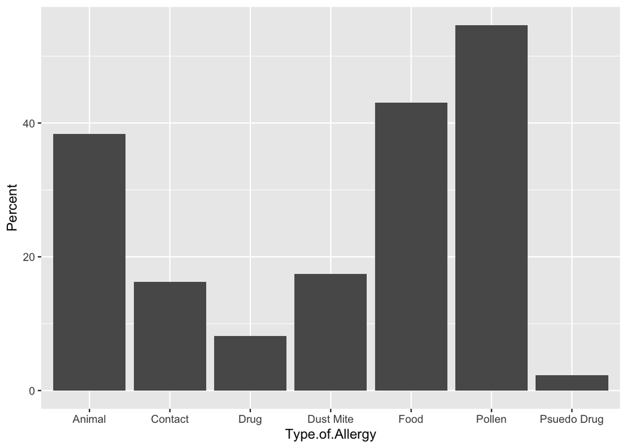

```r
# bar chart of allergies
p_allergies$Type.of.Allergy<-rownames(p_allergies)
plot<- ggplot(data=p_allergies, aes(x = Type.of.Allergy, y=Percent)) +
       geom_bar(stat="identity")
plot
```

```r
# number/percent of AD patients taking each type of medication
meds<- (mtabulate(undup_AD[grep('Medication',names(undup_AD), value=T)]))
meds$Percent<- (meds[,2]/(meds[,1]+meds[,2]))*100
row.names(meds)<- c("Anti-Hypertensive","Anti-Inflammatory","Other Hormones","Thyroid Hormones","Statins", "Insulin","Other")
p_meds<- meds[ ,2:3]
colnames(p_meds)[colnames(p_meds)=="True"]<- "Freq"
p_meds %>% kable(caption = "Medications") %>% kable_styling(bootstrap_options = "striped", full_width = F)
```

Medications

|  | Freq | Percent |
| --- | --- | --- |
| Anti-Hypertensive | 14 | 16.279 |
| Anti-Inflammatory | 8 | 9.302 |
| Other Hormones | 6 | 6.977 |
| Thyroid Hormones | 4 | 4.651 |
| Statins | 7 | 8.139 |
| Insulin | 0 | 0.000 |
| Other | 38 | 44.186 |

```r
# number/percent of AD patients with each type of chronic disease
chrondis<- (mtabulate(undup_AD[grep('chronic',names(undup_AD), value=T)]))
chrondis$Percent<- (chrondis[,2]/(chrondis[,1]+chrondis[,2]))*100
row.names(chrondis)<- c("Hyperlipidemia","Other","Diabetes (non-insulin)","Thyroid Dysfuntion","Asthma", "Hypertension")
p_chrondis<- chrondis[ ,2:3]
colnames(p_chrondis)[colnames(p_chrondis)=="True"]<- "Freq"
p_chrondis %>% kable(caption = "Chronic Disease") %>% kable_styling(bootstrap_options = "striped", full_width = F)
```

Chronic Disease

|  | Freq | Percent |
| --- | --- | --- |
| Hyperlipidemia | 5 | 5.814 |
| Other | 15 | 17.442 |
| Diabetes (non-insulin) | 3 | 3.488 |
| Thyroid Dysfuntion | 5 | 5.814 |
| Asthma | 14 | 16.279 |
| Hypertension | 16 | 18.605 |

```r
# number/percent of AD patients with skin malignancy or other malignancy
malig<- (mtabulate(undup_AD[grep('Malig',names(undup_AD), value=T)]))
malig$Percent<- (malig[,2]/(malig[,1]+malig[,2]))*100
row.names(malig)<- c("Skin malignancy","Other malignancy")
p_malig<- malig[ ,2:3]
colnames(p_malig)[colnames(p_malig)=="True"]<- "Freq"
p_malig %>% kable(caption = "Malignancies") %>% kable_styling(bootstrap_options = "striped", full_width = F)
```

Malignancies

|  | Freq | Percent |
| --- | --- | --- |
| Skin malignancy | 14 | 16.279 |
| Other malignancy | 3 | 3.488 |

```r
# number/percent of AD patients with a family history of AD
famhist<-as.data.frame(addmargins(table(undup_AD$CUSTOM_Fam._hist._Atopic_dermatitis)))
famhist$Percent<- (famhist$Freq/famhist[4,2])*100
famhist<- famhist[2:3, ]
famhist$Var1<- as.factor(c("Family history of AD", "No family history of AD"))
colnames(famhist)[colnames(famhist)=="Freq"]<- "Freq"
colnames(famhist)[colnames(famhist)=="Var1"]<- ""
rownames(famhist) <- NULL
famhist %>% kable(caption = "Family History") %>% kable_styling(bootstrap_options = "striped", full_width = F)
```

Family History

|  | Freq | Percent |
| --- | --- | --- |
| Family history of AD | 37 | 43.02 |
| No family history of AD | 49 | 56.98 |

## Describe the Skin Samples

Counts of lesional status of the skins samples in the AD group.

```r
lesion_tab<- as.data.frame(table(ad_data$lesional))
lesion_tab<- mutate(lesion_tab, Percent=Freq/sum(Freq)*100)
colnames(lesion_tab)[colnames(lesion_tab)=="Var1"]<- ""
lesion_tab %>%
  kable(caption = "Lesional Status of Sample") %>%
  kable_styling(bootstrap_options = "striped", full_width = F)
```

Lesional Status of Sample

|  | Freq | Percent |
| --- | --- | --- |
| Lesional | 83 | 50.61 |
| Non-Lesional | 81 | 49.39 |

## Interpretation

Patients in the AD group are more likely to be male (55.8%).

Nearly the entire group of AD participants (89.5%) are White. According to an article by Kaufman and Alexis[^1], there is evidence that Black individuals may be more prone to eczema than indivdiuals of other races. Yet, Black individuals are also less likely to be treated for the condition[^2]. Due to the racial makeup of the sample available for analysis, genetic differences among the races cannot be compared with the current sample and could be an important revision to future analyes.

The mean age of AD participants is nearly 44 years, with a minimum age of 20 and a maximum age of 83. Due to the ages of individuals included in the sample, an analysis of lesional status based on youth/adult age groups is not possible.

[^1]: Kaufman, B.Alexis, A.(2017). Eczema in skin of color: What you need to know. https://nationaleczema.org/eczema-in-skin-of-color/
[^2]: Fischer, A.H. et al. (2017). Racial and ethnic differences in health care utilization for childhood eczema: An analysis of the 2001-2013 Medical Expenditure Panel Surveys. Journal of American Academy of Dermatology. 77(6). 1060–1067. DOI: https://doi.org/10.1016/j.jaad.2017.08.035
[^3]: McIntosh,J. (2017, Nov 14). What’s to know about eczema? https://www.medicalnewstoday.com/articles/14417.php.